# HSC Survey Results

# Scots Bay Survey # 6 Results from 07/08/2022

## Survey Details

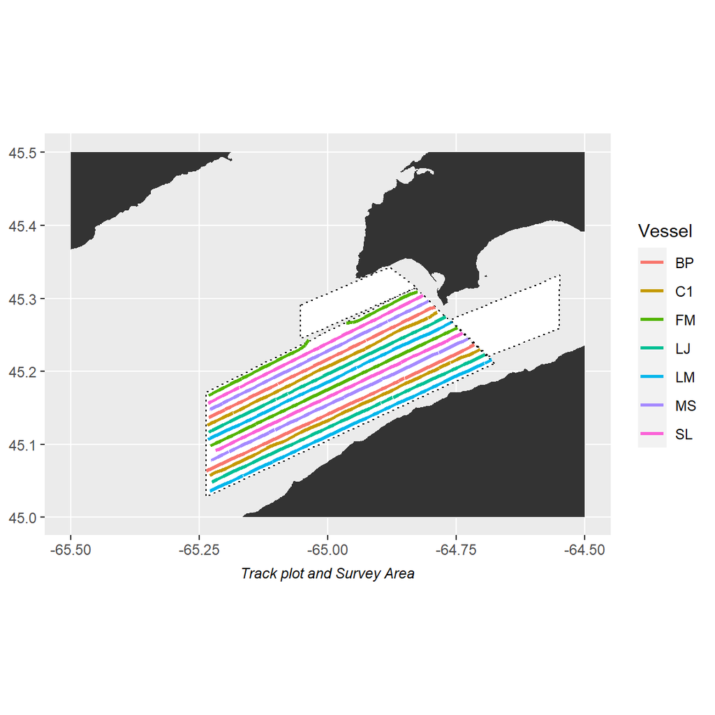

8 commercial purse seiners conducted this fishing survey on 07/08/2022 starting at 21:00:00.

6 vessels ran two transects each in the Main Survey Box, the Morning Star ran four lines in the Eastern Survey Box, and the Brunswick Provider ran four lines in the Northern Survey Box.

There was a plankton tow and replicate conducted and CTD cast by Lady Janice II.

A total of 2,593 tags were applied during the survey over 13 events from 2022-08-03 to 2022-08-11, from 5 vessels.

Samples were obtained for target strength estimation.

### Tides Tables

[figure not shown]

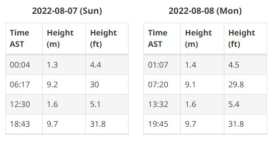

Tide Schedule for Margaretsville NS, Station #315, Source: www.waterlevels.gc.ca

### Acoustic Equipment

Each vessel was equipped with a Simrad ES38-18/200-18C combi (2-in-1) transducer prior to the survey that contains a 38kHz split beam and 200 kHz single beam transducer. Data was logged to the computer hard-drive for post-processing. All participating boats were calibrated on 38kHz before the survey.

## Survey Results

### Main Results

The results are subject to change as DFO will re-evaluate data editing, area estimation and apply a target strength.

**Preliminary biomass prediction for Scots Bay using standardized parallel transects is 5,250mt, and with turnover 3,067mt.**

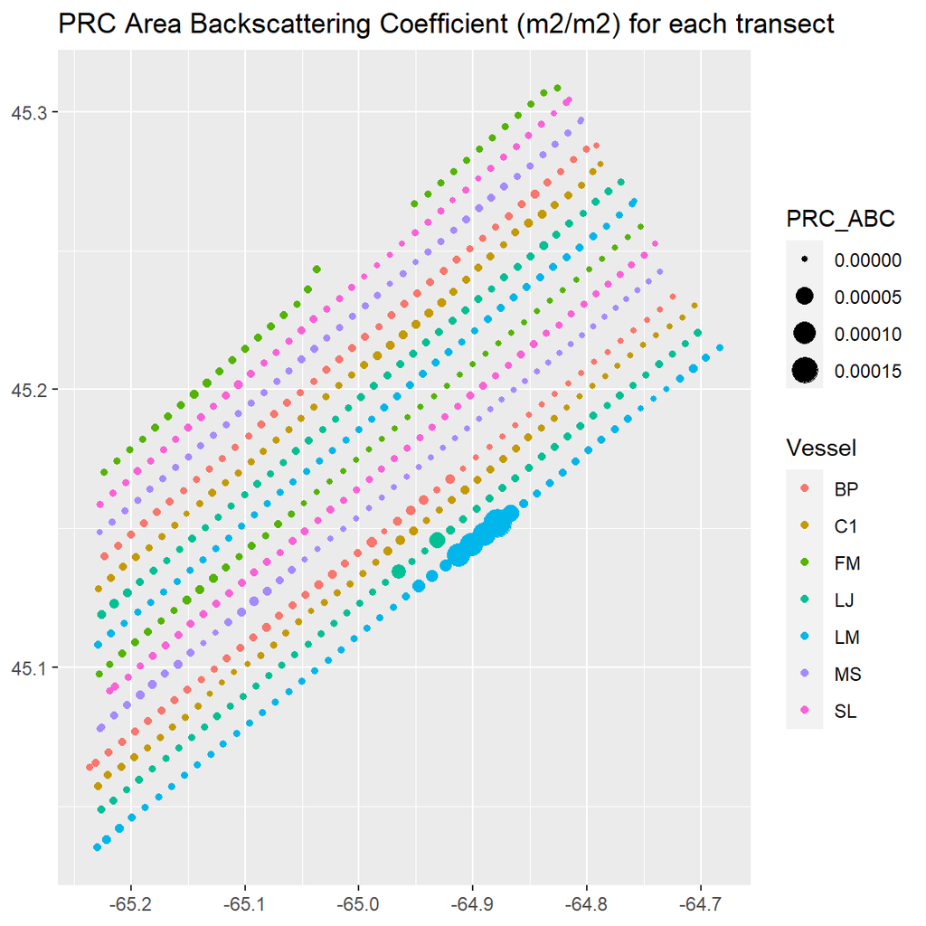

### Transect Details

Table 1: Transect Details

| Vessel | Transect # | Date/Time Start | Date/Time End | Start Lon | Start Lat | End Lon | End Lat | Location | Distance (km) | Speed |
| --- | --- | --- | --- | --- | --- | --- | --- | --- | --- | --- |
| BP | T01 | 2022-08-07 21:01 | 2022-08-07 21:55 | -65.046 | 45.291 | -64.885 | 45.338 | 20 | 13.79 | 8.27 |
| BP | T02 | 2022-08-07 22:00 | 2022-08-07 22:58 | -64.870 | 45.332 | -65.050 | 45.276 | 20 | 15.45 | 8.63 |
| BP | T03 | 2022-08-07 23:03 | 2022-08-08 0:08 | -65.050 | 45.264 | -64.851 | 45.323 | 20 | 17.08 | 8.51 |
| BP | T04 | 2022-08-08 0:13 | 2022-08-08 1:23 | -64.839 | 45.315 | -65.050 | 45.250 | 20 | 18.09 | 8.37 |
| BP | T01 | 2022-08-07 21:01 | 2022-08-07 21:55 | -65.046 | 45.291 | -64.885 | 45.338 | 20 | 13.79 | 8.27 |
| BP | T02 | 2022-08-07 22:00 | 2022-08-07 22:58 | -64.870 | 45.332 | -65.050 | 45.276 | 20 | 15.45 | 8.63 |
| BP | T03 | 2022-08-07 23:03 | 2022-08-08 0:08 | -65.050 | 45.264 | -64.851 | 45.323 | 20 | 17.08 | 8.51 |
| BP | T04 | 2022-08-08 0:13 | 2022-08-08 1:23 | -64.839 | 45.315 | -65.050 | 45.250 | 20 | 18.09 | 8.37 |
| C1 | T01 | 2022-08-07 20:57 | 2022-08-07 23:53 | -65.231 | 45.097 | -64.746 | 45.260 | 20 | 44.12 | 8.12 |
| C1 | T02 | 2022-08-08 0:19 | 2022-08-08 2:37 | -64.828 | 45.311 | -65.238 | 45.165 | 20 | 38.03 | 8.93 |
| FM | T01 | 2022-08-08 21:57 | 2022-08-09 1:20 | -65.231 | 45.073 | -64.720 | 45.242 | 20 | 45.43 | 7.25 |
| FM | T02 | 2022-08-09 1:47 | 2022-08-09 4:06 | -64.811 | 45.290 | -65.234 | 45.144 | 20 | 37.43 | 8.72 |
| LB | T01 | 2022-08-07 20:49 | 2022-08-08 0:35 | -65.235 | 45.083 | -64.733 | 45.251 | 20 | 44.71 | 6.41 |
| LB | T02 | 2022-08-08 1:04 | 2022-08-08 3:24 | -64.811 | 45.303 | -65.232 | 45.155 | 20 | 37.28 | 8.63 |
| LJ | T01 | 2022-08-07 21:00 | 2022-08-08 0:32 | -65.231 | 45.049 | -64.697 | 45.224 | 20 | 46.84 | 7.16 |
| LJ | T02 | 2022-08-08 0:58 | 2022-08-08 3:29 | -64.774 | 45.277 | -65.232 | 45.120 | 20 | 40.19 | 8.62 |
| LM | T01 | 2022-08-07 20:51 | 2022-08-08 0:02 | -65.237 | 45.059 | -64.707 | 45.234 | 20 | 46.49 | 7.89 |
| LM | T02 | 2022-08-08 0:25 | 2022-08-08 2:53 | -64.795 | 45.282 | -65.233 | 45.131 | 20 | 38.61 | 8.45 |
| MS | T01 | 2022-08-07 21:48 | 2022-08-07 22:44 | -64.698 | 45.222 | -64.551 | 45.264 | 20 | 13.04 | 7.54 |
| MS | T02 | 2022-08-07 22:56 | 2022-08-07 23:47 | -64.551 | 45.285 | -64.711 | 45.240 | 20 | 14.07 | 8.94 |
| MS | T03 | 2022-08-08 0:00 | 2022-08-08 1:24 | -64.728 | 45.256 | -64.550 | 45.307 | 20 | 17.13 | 6.61 |
| MS | T04 | 2022-08-08 1:34 | 2022-08-08 2:34 | -64.568 | 45.329 | -64.745 | 45.272 | 20 | 16.21 | 8.75 |
| MS | T01 | 2022-08-07 21:48 | 2022-08-07 22:44 | -64.698 | 45.222 | -64.551 | 45.264 | 20 | 13.04 | 7.54 |
| MS | T02 | 2022-08-07 22:56 | 2022-08-07 23:47 | -64.551 | 45.285 | -64.711 | 45.240 | 20 | 14.07 | 8.94 |
| MS | T03 | 2022-08-08 0:00 | 2022-08-08 1:24 | -64.728 | 45.256 | -64.550 | 45.307 | 20 | 17.13 | 6.61 |
| MS | T04 | 2022-08-08 1:34 | 2022-08-08 2:34 | -64.568 | 45.329 | -64.745 | 45.272 | 20 | 16.21 | 8.75 |
| SL | T01 | 2022-08-07 21:01 | 2022-08-08 0:33 | -65.224 | 45.040 | -64.681 | 45.216 | 20 | 49.55 | 7.57 |
| SL | T02 | 2022-08-08 1:01 | 2022-08-08 3:43 | -64.762 | 45.269 | -65.232 | 45.108 | 20 | 42.82 | 8.56 |

### Survey Summary

Table 2: Acoustic Survey Results

[output not shown]

Note:  
Transects are listed from greatest to least backscatter.

Table 3: Survey Summary Table

[output not shown]

### Greatest Backscatter

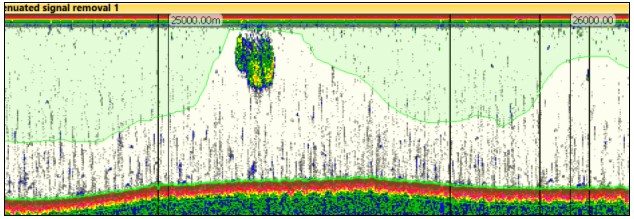

A snip from the transect with the greatest backscatter

The largest backscatter was seen by **LM**, at the following location:

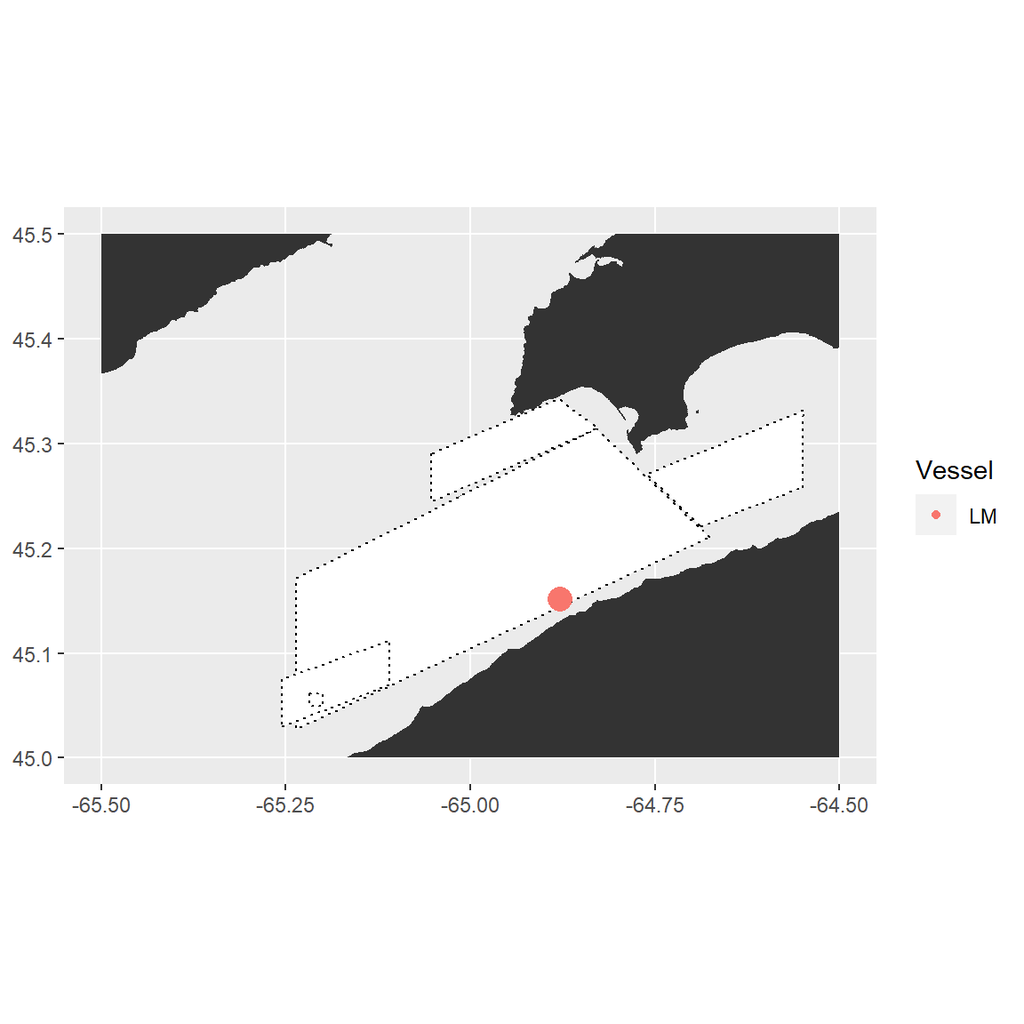

### Annual Summaries

Table 4: Annual Comparison Table

| Ground | Survey Number | Current Year Survey Date | Current Year HSC Estimate | Current Year HSC Turnover Adjusted | Previous Year Survey Date | Previous Year HSC Estimate | Previous Year HSC Turnover Adjusted | Previous Year DFO Estimate | Previous Year DFO Turnover Adjusted |
| --- | --- | --- | --- | --- | --- | --- | --- | --- | --- |
| Scots Bay | 1 | 2022-05-29 | 90,746 | 90,746 | 2021-05-24 | 4,502 | 4,502 | 3,269 | 3,270 |
| Scots Bay | 2 | 2022-06-12 | 104,368 | 92,111 | 2021-06-07 | 13,947 | 13,339 | 2,879 | 2,288 |
| Scots Bay | 3 | 2022-06-26 | 34,199 | 19,781 | 2021-06-19 | 7,056 | 4,685 | 3,739 | 3,268 |
| Scots Bay | 4 | 2022-07-10 | 10,537 | 5,549 | 2021-07-04 | 9,104 | 8,098 | 6,317 | 5,861 |
| Scots Bay | 5 | 2022-07-26 | 13,060 | 11,904 | 2021-07-17 | 4,985 | 3,602 | 2,949 | 1,994 |
| Scots Bay | 6 | 2022-08-07 | 5,250 | 3,067 | 2021-08-02 | 10,364 | 9,817 | 4,922 | 4,540 |
| Scots Bay | 7 | 2022-08-21 | 4,392 | 3,453 | 2021-08-15 | 7,705 | 6,159 | 4,670 | 4,006 |
| Scots Bay | 8 | 2022-09-05 | 21,908 | 21,372 | 2021-08-29 | 3,602 | 2,453 | 3,876 | 3,228 |
| Scots Bay | 9 | 2022-09-18 | 8,133 | 4,850 | 2021-09-13 | 38,584 | 38,109 | 38,224 | 36,587 |
| Scots Bay | 10 | 2022-10-03 | NA | NA | 2021-09-26 | 1,456 | 0 | 2,716 | 0 |

Table 5: Annual Summary Table

| Year | Ground | HSC Estimate | HSC Turnover Adjusted | DFO Estimate | DFO Turnover Adjusted |
| --- | --- | --- | --- | --- | --- |
| 2021 | Scots Bay | 101,305 | 90,764 | 73,561 | 65,042 |
| 2022 | Scots Bay | NA | NA | NA | NA |

## Tagging, Plankton, and CTD Data

### Tag Data

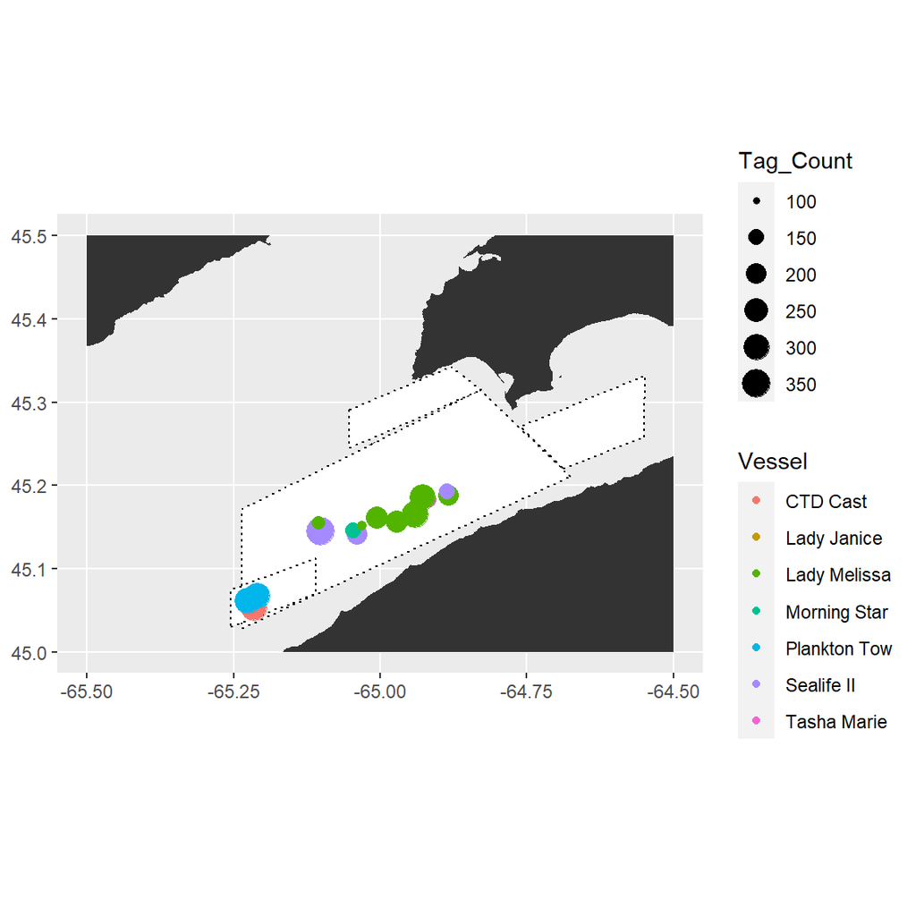

| Vessel | Tags |
| --- | --- |
| Lady Janice | 99 |
| Lady Melissa | 1501 |
| Morning Star | 150 |
| Sealife II | 700 |
| Tasha Marie | 143 |

### Plankton Data

#### Tow Summary Table

|  | Tow 1 | Tow 2 |
| --- | --- | --- |
| **Base Details** |  |  |
| Vessel | Lady Janice II | Lady Janice II |
| Set Number | SB2022-11 | SB2022-12 |
| Ground | SB | SB |
| Date | 07/08/2022 | 07/08/2022 |
| Wind Direction (km/h) | SW | SW |
| Swell (m) | 1 | 1 |
| Air Temp (c) | 25 | 25 |
| **Tow Details** |  |  |
| Tow Start | 18:41:00 | 18:55:00 |
| Tow End | 18:51:00 | 19:05:00 |
| Start Lat | 45.0615 | 45.0673 |
| End Lat | 45.0680 | 45.0655 |
| Start Lon | -65.2268 | -65.2097 |
| End Lon | -65.2127 | -65.2153 |
| Avg Tow Depth (m) | 4.74 | 1.61 |
| Speed | 4.5 | 2.0 |
| Heading | 60 | 247 |
| Tide Direction | with | against |
| **Other Data Collection** |  |  |
| Flow Start | 896175 | 924397 |
| Flow End | 924397 | 960589 |
| No. Revolutions | 28222 | 36192 |
| Distance (m) | 758.41 | 972.59 |
| Volume | 2382.62 | 3055.47 |
| Secchi Disappear (m) | NA | NA |
| Secchi Reappear (m) | NA | NA |

#### Tow Depth Profiles

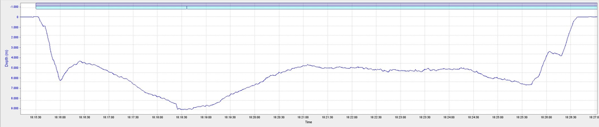

Plankton tow depth profile #1

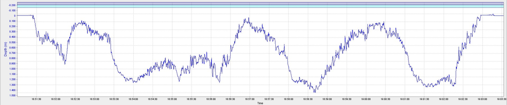

Plankton tow depth profile #2

The first tow is SB2022-11, which was with the tide and had an average depth of 4.74m. The second tow is SB2022-12, which was against the tide and had an average depth of 1.61m.

#### Captured plankton

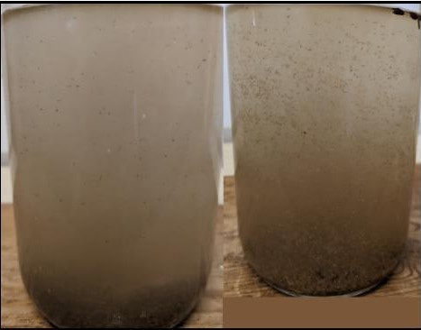

Captured plankton from the surface tows

### CTD Data

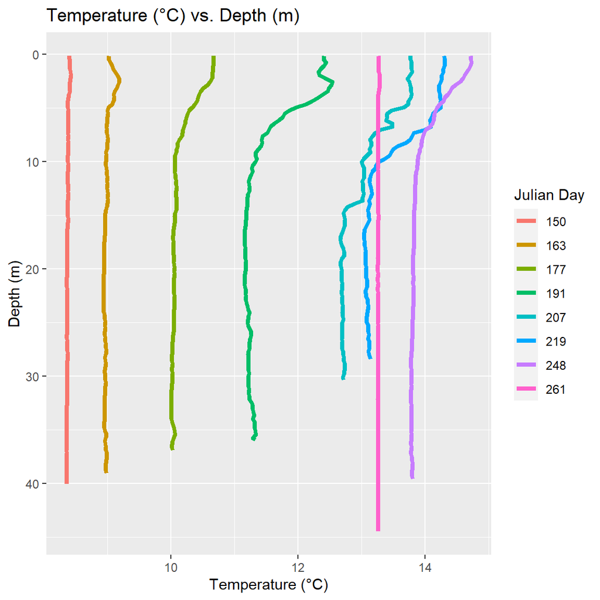

CTD depth profiles for all 2022 Scots Bay surveys so far.

#### Sea surface temperatures

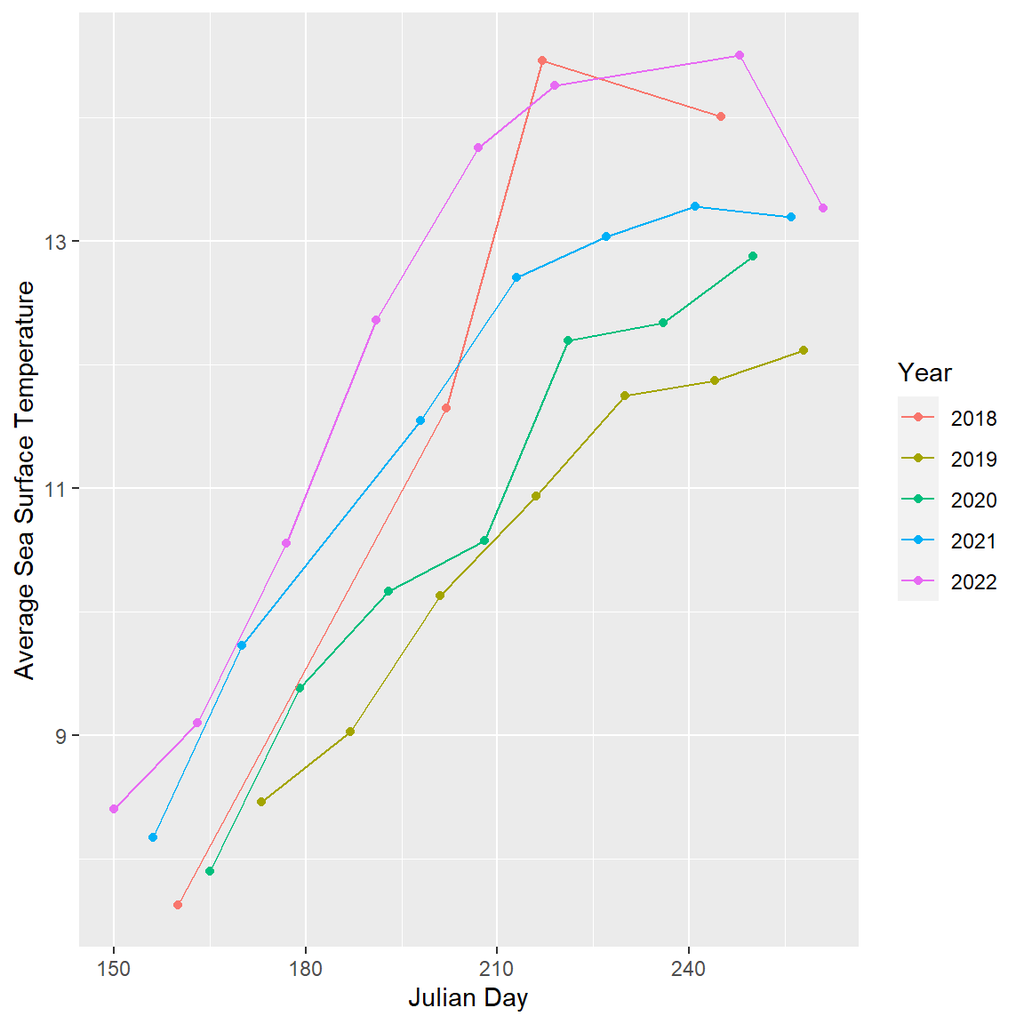

Annual average sea surface temperatures (SST) for Scots Bay.

## Vessel Performance

### Speed

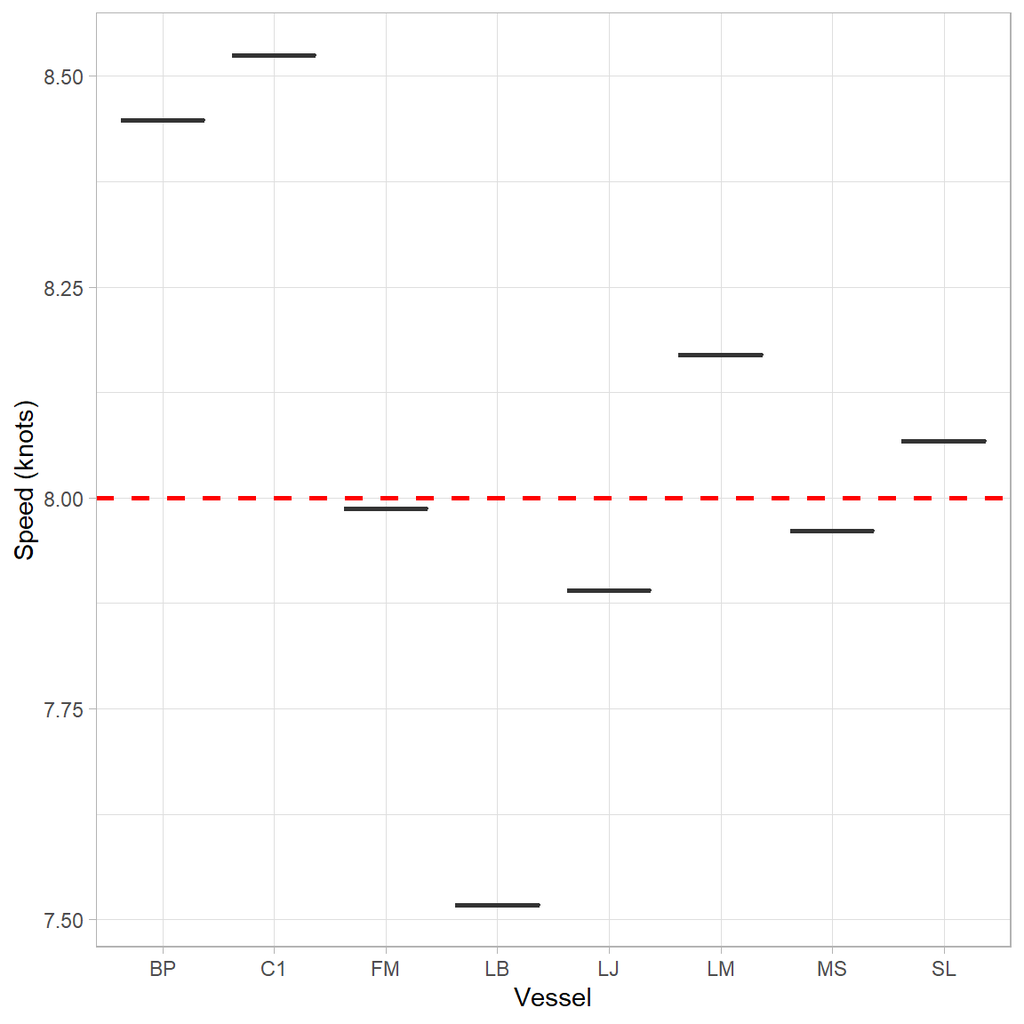

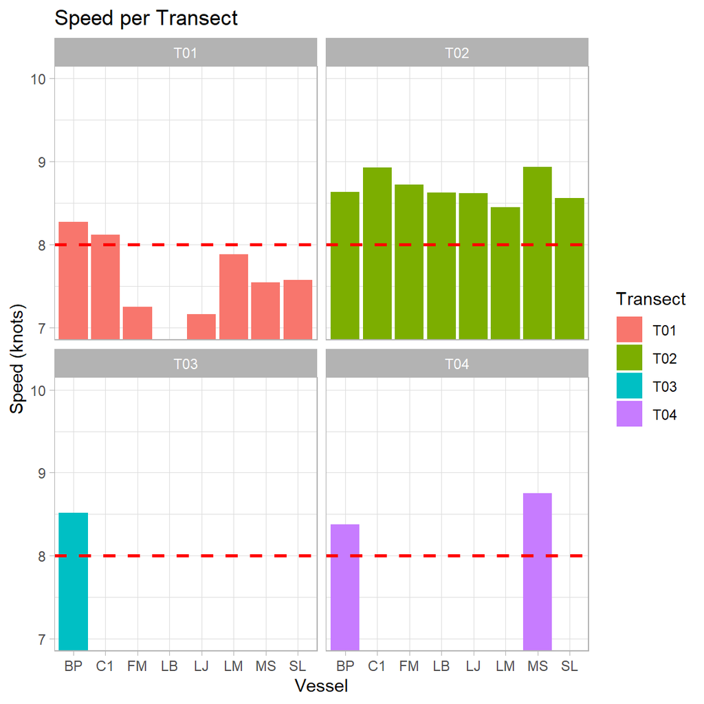

Average vessel speed was 8.07. This is above the 8 knot requirement; vessels are urged to slow down to prevent backscatter noise from interfering with the acoustic data.

### Distance

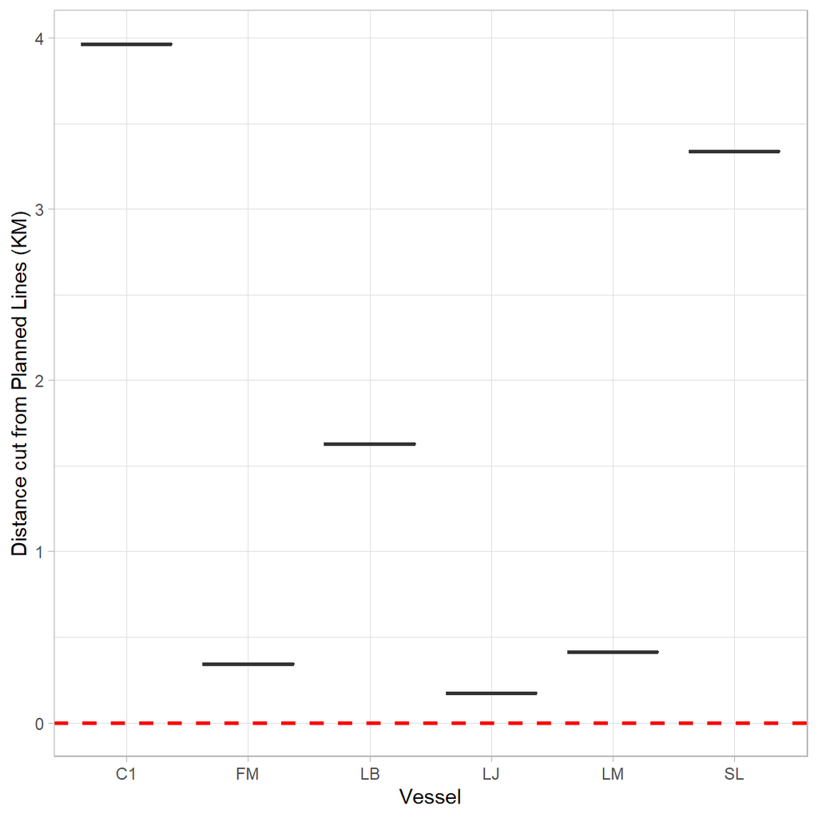

More than 2km of distance was cut from the planned lines; vessels are reminded to complete their assigned lines straight and without deviating or cutting corners short.